# R

## Overview

## What do you expect to learn?

[figure not shown]

## Hint

R is a programming *language* (Scripting language)

- Vocabulary
- Grammar

### Learning by doing!

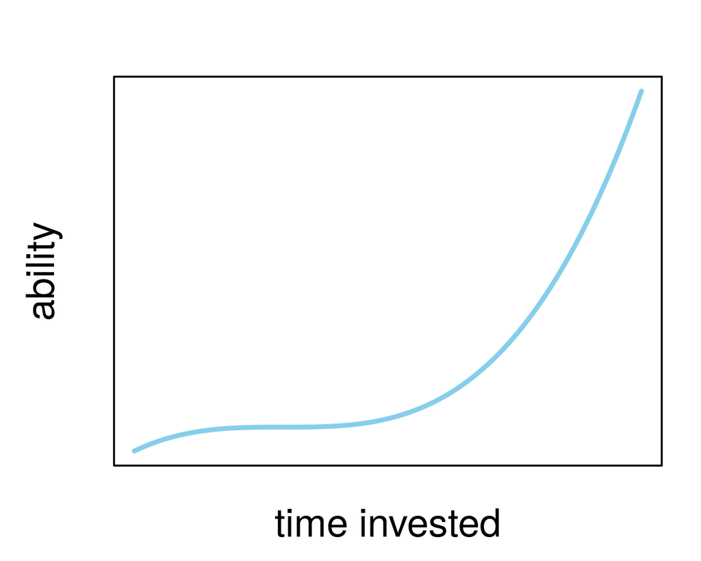

## Overview

1. Get help
2. Basic `R` functionality
3. Use a `function()`
4. Read data files from the internet
5. Basic graphing
6. Write a `function()`

## FRst Experiments & Help

## Trial & Error 1

**Have a crack at the R console.**

```r
help.start()
citation()
sessionInfo()
```

## HELP!

### "How do I do this?" or "Why is it not working?"

Google

- [StackOverflow](http://stackoverflow.com/)
- [Cross-Validate](http://stats.stackexchange.com/)
- R email lists
- blogs

In R

```r
?sum
?mean
help("sd")

??correlation
```

## R basics

## R as a calculator

```r
1+1
```

```
## [1] 2
```

```r
12^4
```

```
## [1] 20736
```

```r
log(23)
```

```
## [1] 3.135494
```

## R as a fancy calculator

### Variables

```r
x <- 10
y <- 6
x + y
```

```
## [1] 16
```

```r
z <- x + y
y/z
```

```
## [1] 0.375
```

## R as a fancy calculator

### Variables

*Warning: R is case sensitive.*

```r
X <- 5 # Does not replace variable x
x
```

```
## [1] 10
```

## Variables

You can save any kind of information as variables.

```r
name <- "Jed Bartlet"  # Character
age <- 65           # Integer / Double
president <- TRUE         # Boolean
```

Variables are called *objects*

- vector (`c()`)
- `matrix()`
- `data.frame()`
- `list()`

## Vectors

```r
staff <- c("Josh", "CJ", "Sam")
staff
```

```
## [1] "Josh" "CJ"   "Sam"
```

### Indexing Objects

```r
staff[2]
```

```
## [1] "CJ"
```

```r
staff[c(1, 3)]
```

```
## [1] "Josh" "Sam"
```

## Matrices

Matrices are "tables" with at least one row and one column.

```r
m # A matrix
```

```
##      [,1] [,2] [,3]
## [1,]    1    4    7
## [2,]    2    5    8
## [3,]    3    6    9
```

## Trial & Error 2

**Make a matrix `m` with the help of the function `matrix`. How can matrices be indexed?**

```r
?matrix
```

## Trial & Error 2

**Make a matrix `m` with the help of the function `matrix`. How can matrices be indexed?**

```r
m <- matrix(c(1:9), nrow = 3)
m[1, ] # First row
```

```
## [1] 1 4 7
```

```r
m[, 3] # Third column
```

```
## [1] 7 8 9
```

```r
m[1, 3] # Element in the first row and third column
```

```
## [1] 7
```

## data.frame

Vectors and matrices can only contain one data type.

```r
(x <- c(1:3))
```

```
## [1] 1 2 3
```

```r
(x <- c(1:3, "four")) # all elements become characters
```

```
## [1] "1"    "2"    "3"    "four"
```

The data we analyze are different types.

## data.frame

A `data.frame` is

- a table similar to a matrix
- can contain different data types
- usually has column names

I usually use `data.frame`s for my data.

The structure of the data should be

- one observation per row
- one variable per column

## Trial & Error 3

New data:

```r
name <- c("Ben", "Kathy", "Paul", "Julia", "Jeff")
age <- c(24, 43, 32, 27, 60)
job <- rep("teacher", 5)
friends <- c(5, 2, 0, 3, 6)
pets <- c(0, 2, 4, 1, 1)
income <- c(":/", ":)", ":(", ":(", ":)")

teachers <- data.frame(name, age, job, friends, pets, income)
save(teachers, file = "data/teachers.RData")
```

## Trial & Error 3

**Load data `teachers.RData` or make the data frame yourself. Calculate the pets to friends ratio and add this variable to the `data.frame`.**

**Calculate the average age for happy-face income and sad-face income.**

## Trial & Error 3

**Calculate the pets to friends ratio and add this variable to the `data.frame`.**

```r
teachers$ratio <- teachers$pets / teachers$friends
teachers
```

```
##    name age     job friends pets income     ratio
## 1   Ben  24 teacher       5    0     :/ 0.0000000
## 2 Kathy  43 teacher       2    2     :) 1.0000000
## 3  Paul  32 teacher       0    4     :(       Inf
## 4 Julia  27 teacher       3    1     :( 0.3333333
## 5  Jeff  60 teacher       6    1     :) 0.1666667
```

## Trial & Error 3

**Calculate the average age for happy-face income and sad-face income.**

```r
mean(teachers$age[teachers$income == ":)"])
```

```
## [1] 51.5
```

```r
tapply(teachers$age, teachers$income, mean)
```

```
##   :(   :)   :/
## 29.5 51.5 24.0
```

## Swirl

Try out the R-package `swirl`.

```r
install.packages("swirl")
library("swirl")

install_from_swirl("R Programming")
swirl()
#try 10: lapply and sapply
#try 11: vapply and tapply
```

## Deliberately use a function

## Example

```r
head(dat.fun)
```

```
##   sub         x         y
## 1   1 11.506622 12.790105
## 2   2 14.028709 16.726839
## 3   3  9.289731  9.197381
## 4   4 14.056336  9.573260
## 5   5  5.566251  9.977233
## 6   6 11.516792  8.716706
```

## Analysis of this boring data set

- We want to analyse this data set with a \(t\)-test
- We need two functions:
- One to read in the data (`read.csv`)
- One to conduct the \(t\)-test (`t.test`)

## read.csv

```r
?read.csv
```

It shows several related functions. `read.csv` has several *arguments*, most of them have a *default setting*.

Minimal usage: Submit the filename to `read.csv`.

```r
example.dat <- read.csv(file = "day1/intro-to-R/data/example_fun.csv")
head(example.dat)
```

```
##   sub         x         y
## 1   1 11.506622 12.790105
## 2   2 14.028709 16.726839
## 3   3  9.289731  9.197381
## 4   4 14.056336  9.573260
## 5   5  5.566251  9.977233
## 6   6 11.516792  8.716706
```

## Trial & Error 4: t-test

**Use `help()` to navigate the `t-test` function. What arguments to you need to submit to the function? What are the results?**

## Trial & Error 4: t-test

**Use `help()` to navigate the `t-test` function. What arguments to you need to submit to the function? What are the results?**

```r
?t.test
```

Easiest usage: submit x and y. You can choose one- or two-sided hypotheses, one-sample or paired *t*-test (default is between-participant) and whether variances are assumed to be equal or not…

```r
t.test(example.dat$x, example.dat$y, var.equal = T)
```

```
##
##  Two Sample t-test
##
## data:  example.dat$x and example.dat$y
## t = -3.0217, df = 98, p-value = 0.003206
## alternative hypothesis: true difference in means is not equal to 0
## 95 percent confidence interval:
##  -3.0740080 -0.6369304
## sample estimates:
## mean of x mean of y
##  9.870395 11.725864
```

## Actual Data in R

## Getting data into R

- We used the `read.csv` function before.
- But what if you want data from another source?
- Like the internet?
- wmPNAS2008

## curl

```r
daturl <- curl::curl("https://raw.githubusercontent.com/PerceptionCognitionLab/data0/master/wmPNAS2008/lk2clean.csv")
dat <- read.csv(daturl, header = T)

head(dat)
```

```
##   X.1 X sub blk trl prch drawnoncued N ischange resp       RT probesq
## 1   1 1   0   0   0  0.3           0 2        0    0 1.274988       0
## 2   2 2   0   0   1  0.3           0 2        0    0 0.961366       0
## 3   3 3   0   0   2  0.3           0 8        0    0 1.073023       7
## 4   4 4   0   0   3  0.3           0 2        0    0 0.830884       1
## 5   5 5   0   0   4  0.3           0 2        1    1 1.145182       0
## 6   6 6   0   0   5  0.3           0 2        0    0 0.858341       1
##   newcol c1  x1  y1 c2  x2  y2 c3  x3  y3 c4  x4  y4 c5  x5  y5 c6  x6  y6
## 1   cyan  8 613 396  9 527 451 NA  NA  NA NA  NA  NA NA  NA  NA NA  NA  NA
## 2  black  1 471 311  5 478 437 NA  NA  NA NA  NA  NA NA  NA  NA NA  NA  NA
## 3  green  6 451 465  7 414 340 10 560 448  8 619 347  1 478 326  2 575 390
## 4 yellow  1 584 352  7 432 416 NA  NA  NA NA  NA  NA NA  NA  NA NA  NA  NA
## 5 yellow  5 566 350  2 393 464 NA  NA  NA NA  NA  NA NA  NA  NA NA  NA  NA
## 6  green  6 583 350  4 509 457 NA  NA  NA NA  NA  NA NA  NA  NA NA  NA  NA
##   c7  x7  y7 c8  x8  y8  cor oldcol  avgdist avgdistcen prbdistcen
## 1 NA  NA  NA NA  NA  NA TRUE   cyan 102.0833   85.18447  101.71037
## 2 NA  NA  NA NA  NA  NA TRUE  black 126.1943   73.34699   83.72574
## 3  5 634 411  4 555 331 TRUE  green 126.9315   90.71984   68.24954
## 4 NA  NA  NA NA  NA  NA TRUE yellow 164.9242   82.47675   86.16264
## 5 NA  NA  NA NA  NA  NA TRUE   blue 207.1835  103.60165   63.81222
## 6 NA  NA  NA NA  NA  NA TRUE  green 130.0961   75.89132   73.06162
##   avgdistpr
## 1  102.0833
## 2  126.1943
## 3  106.5541
## 4  164.9242
## 5  207.1835
## 6  130.0961
```

## Let's make it prettier

```r
dat.pretty <- dat[, c("sub", "blk", "trl", "prch", "N", "ischange", "resp")]
dat.pretty$accuracy <- dat.pretty$ischange == dat.pretty$resp

dat.pretty$ischange <- factor(dat.pretty$ischange, labels = c("unchanged", "changed"))

head(dat.pretty)
```

```
##   sub blk trl prch N  ischange resp accuracy
## 1   0   0   0  0.3 2 unchanged    0     TRUE
## 2   0   0   1  0.3 2 unchanged    0     TRUE
## 3   0   0   2  0.3 8 unchanged    0     TRUE
## 4   0   0   3  0.3 2 unchanged    0     TRUE
## 5   0   0   4  0.3 2   changed    1     TRUE
## 6   0   0   5  0.3 2 unchanged    0     TRUE
```

## Analyze it

```r
mean.acc <- with(dat.pretty, tapply(accuracy, list(prch, N, ischange), mean))
mean.acc
```

```
## , , unchanged
##
##             2         5         8
## 0.3 0.9481865 0.8074922 0.6981328
## 0.5 0.9317852 0.7223837 0.6113537
## 0.7 0.8934625 0.6699029 0.4866828
##
## , , changed
##
##             2         5         8
## 0.3 0.9249395 0.8062954 0.6447689
## 0.5 0.9651669 0.8617176 0.7671033
## 0.7 0.9689119 0.9191710 0.8681205
```

## Plot it?

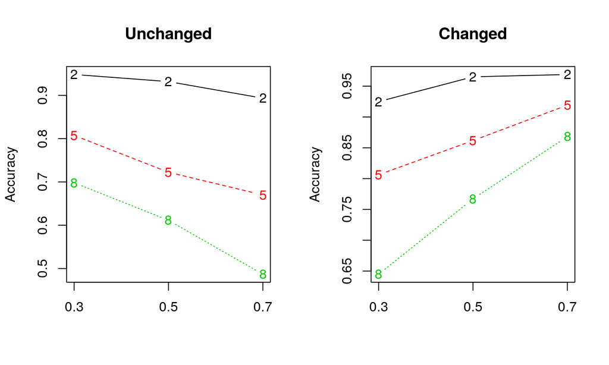

## Plot it

```r
mean.acc[,,1]
```

```
##             2         5         8
## 0.3 0.9481865 0.8074922 0.6981328
## 0.5 0.9317852 0.7223837 0.6113537
## 0.7 0.8934625 0.6699029 0.4866828
```

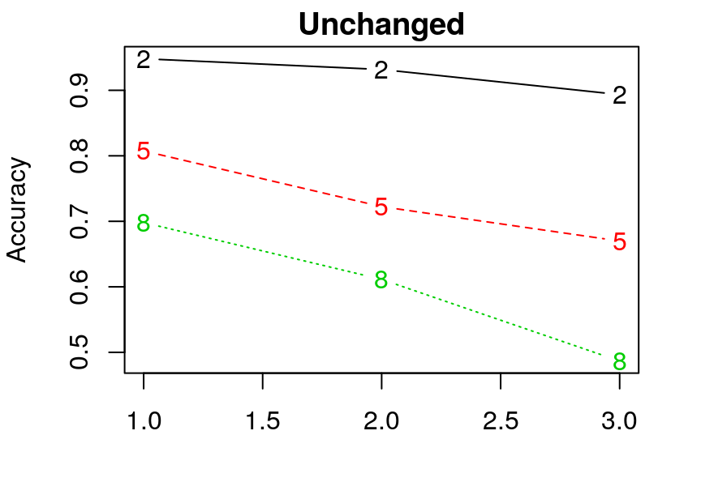

```r
matplot(mean.acc[,,1] # data
        , main = "Unchanged", ylab = "Accuracy" #labels: title and y-axis
        , type = "b", pch = colnames(mean.acc)) #type = "both" line and point, point type = set size
```

## Counting

```r
(tab <- table(dat.pretty$resp, dat.pretty$ischange))
```

```
##
##     unchanged changed
##   0      4769     771
##   1      1423    5422
```

## Counting

```r
tab
```

```
##
##     unchanged changed
##   0      4769     771
##   1      1423    5422
```

- Hits, misses, false alarms, correct rejections

## Counting

```r
tab
```

```
##
##     unchanged changed
##   0      4769     771
##   1      1423    5422
```

- Hits, misses, false alarms, correct rejections

```r
(outcomes <- c("hits" = tab[2, 2], "misses" = tab[1, 2]
              , "fa" = tab[2, 1], "cr" = tab[1, 1]))
```

```
##   hits misses     fa     cr
##   5422    771   1423   4769
```

## Plot counts

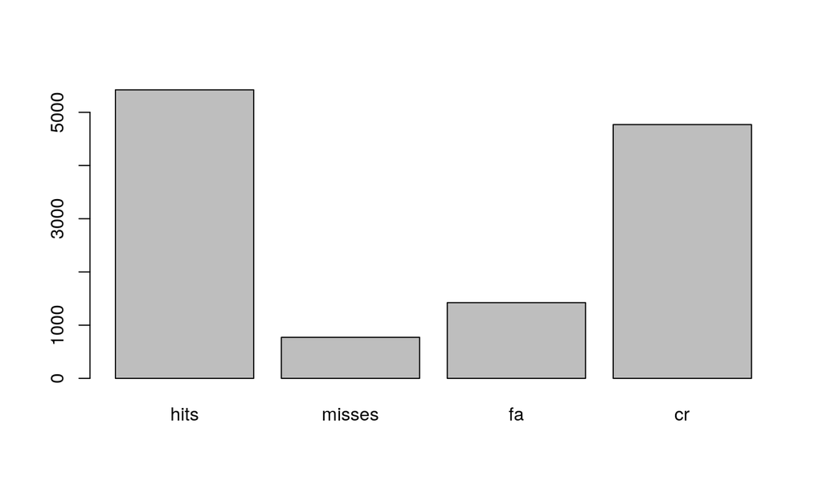

```r
barplot(outcomes)
```

## Plot counts

Go crazy on the [colors!](http://www.stat.columbia.edu/~tzheng/files/Rcolor.pdf)

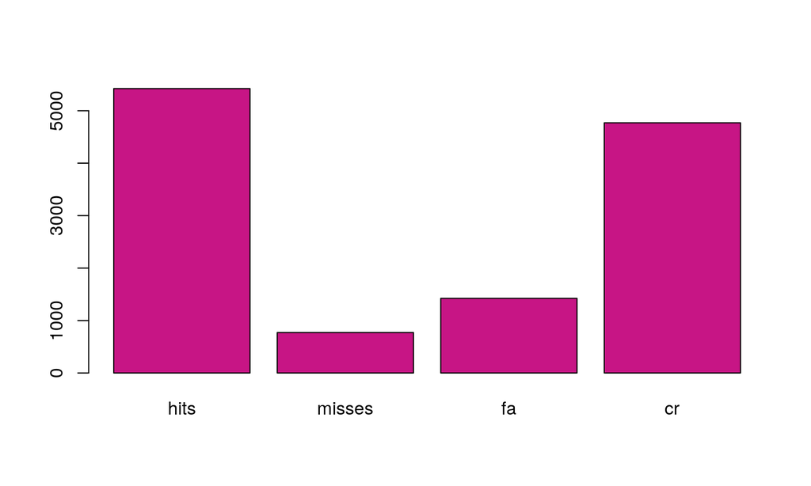

```r
barplot(outcomes, col = "mediumvioletred")
```

## Programming in R

## Functions

- You use them in data analysis all the time
- i.e. `mean()`, `plot()`, `t.test()`,…
- But you can also write your own!

## Write your own function

### Hello world!

```r
hello <- function(){
  return("Hello World!")
}

hello()
```

```
## [1] "Hello World!"
```

## Write your own function

### Calculator

Goal: A function that takes two numbers as arguments and returns the sum of them.

## Write your own function

### Calculator

Goal: A function that takes two numbers as arguments and returns the sum of them.

```r
gimme.sum <- function(x, y){
  sum.xy <- x + y
  return(sum.xy)
}

gimme.sum(99, 567)
```

```
## [1] 666
```

## Write your own function

### Calculator

Goal: A function that takes two numbers as arguments and returns the sum of them.

```r
gimme.sum <- function(x, y){
  sum.xy <- x + y
  return(sum.xy)
}

gimme.sum(c(1, 2, 5, 7), 567)
```

```
## [1] 568 569 572 574
```

## Write your own function

### Your turn!

Goal: A function that takes two vectors of numbers, x and y, and returns a vector with length of x with \(\frac{x}{sd_y}\).

## Write your own function

### Your turn!

Goal: A function that takes two vectors of numbers, x and y, and returns a vector with length of x with \(\frac{x}{sd_y}\).

```r
what <- function(x, y){
  sdy <- sd(y)
  return(x/sdy)
}
```

## Write your own function

### Your turn!

Goal: A function that takes two vectors of numbers, x and y, and returns a vector with length of x with \(\frac{x}{sd_y}\).

```r
what <- function(x, y){
  sdy <- sd(y)
  return(x/sdy)
}

what(c(1, 2, 3), c(1, 4, 7))
```

```
## [1] 0.3333333 0.6666667 1.0000000
```

```r
what(1:3, c(1, 1, 1))
```

```
## [1] Inf Inf Inf
```